# National Parks Biodiversity Analysis Portfolio Project

## Executive Summary

This comprehensive data science project demonstrates advanced Python capabilities in data extraction, cleaning, visualization, and statistical analysis using real-world biodiversity data from U.S. National Parks. The analysis reveals critical insights into species distribution, conservation patterns, and park-specific biodiversity metrics.

## Project Objectives

- **Data Engineering**: Load, clean, and transform biodiversity datasets
- **Exploratory Data Analysis**: Uncover patterns in species distribution and conservation status
- **Statistical Analysis**: Perform hypothesis testing to validate findings
- **Data Visualization**: Create compelling visualizations to communicate insights
- **Business Intelligence**: Generate actionable recommendations for conservation efforts

## Dataset Overview

- **observations.csv**: Species observation counts across national parks
- **species_info.csv**: Comprehensive species information including taxonomy and conservation status
- **Analysis Period**: Multi-year biodiversity survey data
- **Scope**: Four major U.S. National Parks

## Key Technologies Demonstrated

- **Python Libraries**: pandas, numpy, matplotlib, seaborn, scipy
- **Data Analysis**: Statistical testing, hypothesis validation
- **Visualization**: Professional-grade charts and insights
- **Documentation**: Comprehensive reporting and analysis interpretation

```python
# Load necessary libraries for data analysis and visualization
import pandas as pd
import numpy as np
import matplotlib.pyplot as plt
import seaborn as sns
from scipy import stats
import warnings
warnings.filterwarnings('ignore')

# Set plotting style for professional visualizations
plt.style.use('seaborn-v0_8')
sns.set_palette("husl")

print("Loading biodiversity datasets...")

try:
    # Load the primary datasets
    observations_df = pd.read_csv('observations.csv')
    species_info_df = pd.read_csv('species_info.csv')

    print("Data loaded successfully!")
    print(f"Observations dataset: {observations_df.shape[0]:,} records, {observations_df.shape[1]} columns")
    print(f"Species info dataset: {species_info_df.shape[0]:,} records, {species_info_df.shape[1]} columns")

except FileNotFoundError as e:
    print(f"Error loading data: {e}")
    print("Please ensure the CSV files are in the same directory as this notebook.")

# Display the first few rows of each DataFrame for initial inspection
print("\nSample of Observations Data:")
observations_df.head()
```

```
Loading biodiversity datasets...
Data loaded successfully!
Observations dataset: 23,296 records, 3 columns
Species info dataset: 5,824 records, 4 columns

Sample of Observations Data:
```

|  | scientific_name | park_name | observations |
| --- | --- | --- | --- |
| 0 | Vicia benghalensis | Great Smoky Mountains National Park | 68 |
| 1 | Neovison vison | Great Smoky Mountains National Park | 77 |
| 2 | Prunus subcordata | Yosemite National Park | 138 |
| 3 | Abutilon theophrasti | Bryce National Park | 84 |
| 4 | Githopsis specularioides | Great Smoky Mountains National Park | 85 |

# Data Engineering & Initial Exploration

## 1. Data Loading and Library Import

Loading essential Python libraries for data manipulation, statistical analysis, and visualization. This demonstrates proficiency with the core data science stack in Python.

```python
print("Sample of Species Information Data:")
species_info_df.head()
```

```
Sample of Species Information Data:
```

|  | category | scientific_name | common_names | conservation_status |
| --- | --- | --- | --- | --- |
| 0 | Mammal | Clethrionomys gapperi gapperi | Gapper's Red-Backed Vole | NaN |
| 1 | Mammal | Bos bison | American Bison, Bison | NaN |
| 2 | Mammal | Bos taurus | Aurochs, Aurochs, Domestic Cattle (Feral), Dom... | NaN |
| 3 | Mammal | Ovis aries | Domestic Sheep, Mouflon, Red Sheep, Sheep (Feral) | NaN |
| 4 | Mammal | Cervus elaphus | Wapiti Or Elk | NaN |

```python
# Comprehensive data quality assessment
print("=" * 60)
print("OBSERVATIONS DATASET - DATA QUALITY REPORT")
print("=" * 60)

print(f"Dataset Shape: {observations_df.shape}")
print(f"Memory Usage: {observations_df.memory_usage(deep=True).sum() / 1024**2:.2f} MB")
print("\nColumn Information:")
observations_df.info()

print(f"\nMissing Values Summary:")
missing_obs = observations_df.isnull().sum()
print(missing_obs[missing_obs > 0] if missing_obs.sum() > 0 else "No missing values detected")

print("\n" + "=" * 60)
print("SPECIES INFO DATASET - DATA QUALITY REPORT")
print("=" * 60)

print(f"Dataset Shape: {species_info_df.shape}")
print(f"Memory Usage: {species_info_df.memory_usage(deep=True).sum() / 1024**2:.2f} MB")
print("\nColumn Information:")
species_info_df.info()

print(f"\nMissing Values Analysis:")
missing_species = species_info_df.isnull().sum()
for col in missing_species.index:
    if missing_species[col] > 0:
        percent_missing = (missing_species[col] / len(species_info_df)) * 100
        print(f"  {col}: {missing_species[col]:,} missing ({percent_missing:.1f}%)")

print(f"\nUnique Values per Column:")
for col in species_info_df.columns:
    unique_count = species_info_df[col].nunique()
    print(f"  {col}: {unique_count:,} unique values")
```

```
============================================================
OBSERVATIONS DATASET - DATA QUALITY REPORT
============================================================
Dataset Shape: (23296, 3)
Memory Usage: 3.37 MB

Column Information:
<class 'pandas.core.frame.DataFrame'>
RangeIndex: 23296 entries, 0 to 23295
Data columns (total 3 columns):
 #   Column           Non-Null Count  Dtype
---  ------           --------------  -----
 0   scientific_name  23296 non-null  object
 1   park_name        23296 non-null  object
 2   observations     23296 non-null  int64
dtypes: int64(1), object(2)
memory usage: 546.1+ KB

Missing Values Summary:
No missing values detected

============================================================
SPECIES INFO DATASET - DATA QUALITY REPORT
============================================================
Dataset Shape: (5824, 4)
Memory Usage: 1.33 MB

Column Information:
<class 'pandas.core.frame.DataFrame'>
RangeIndex: 5824 entries, 0 to 5823
Data columns (total 4 columns):
 #   Column               Non-Null Count  Dtype
---  ------               --------------  -----
 0   category             5824 non-null   object
 1   scientific_name      5824 non-null   object
 2   common_names         5824 non-null   object
 3   conservation_status  191 non-null    object
dtypes: object(4)
memory usage: 182.1+ KB

Missing Values Analysis:
  conservation_status: 5,633 missing (96.7%)

Unique Values per Column:
  category: 7 unique values
  scientific_name: 5,541 unique values
  common_names: 5,504 unique values
  conservation_status: 4 unique values
```

## 2. Data Quality Assessment & Profiling

Conducting comprehensive data quality checks to identify potential issues, missing values, and data types. This step is crucial for ensuring reliable analysis results.

### Data Quality Insights

**Analytical Implications:**

- Conservation status analysis will focus on species WITH known status
- Missing conservation data likely represents "Least Concern" or unstudied species
- High data quality in observations enables robust statistical analysis

```python
# Generate comprehensive descriptive statistics
print("DESCRIPTIVE STATISTICS ANALYSIS")
print("=" * 50)

print("\nObservations Dataset - Numerical Summary:")
obs_stats = observations_df.describe()
print(obs_stats)

# Additional statistics for observations
print(f"\nObservation Distribution Insights:")
print(f"  • Total Observations Recorded: {observations_df['observations'].sum():,}")
print(f"  • Mean Observations per Species: {observations_df['observations'].mean():.1f}")
print(f"  • Median Observations: {observations_df['observations'].median():.1f}")
print(f"  • Standard Deviation: {observations_df['observations'].std():.1f}")
print(f"  • Coefficient of Variation: {(observations_df['observations'].std() / observations_df['observations'].mean() * 100):.1f}%")

print(f"\nParks Covered: {observations_df['park_name'].nunique()} parks")
for park in observations_df['park_name'].unique():
    count = len(observations_df[observations_df['park_name'] == park])
    print(f"  • {park}: {count:,} species records")

print("\nSpecies Information Dataset - Categorical Summary:")
print(f"  • Total Species: {species_info_df.shape[0]:,}")
print(f"  • Species Categories: {species_info_df['category'].nunique()}")
print(f"  • Conservation Statuses: {species_info_df['conservation_status'].nunique()} (excluding NaN)")

print("\nSpecies Category Distribution:")
category_counts = species_info_df['category'].value_counts()
for category, count in category_counts.items():
    percentage = (count / len(species_info_df)) * 100
    print(f"  • {category}: {count:,} species ({percentage:.1f}%)")

print("\nConservation Status Distribution (Non-null only):")
conservation_counts = species_info_df['conservation_status'].value_counts(dropna=True)
total_with_status = conservation_counts.sum()
for status, count in conservation_counts.items():
    percentage = (count / total_with_status) * 100
    print(f"  • {status}: {count:,} species ({percentage:.1f}% of classified species)")
```

```
DESCRIPTIVE STATISTICS ANALYSIS
==================================================

Observations Dataset - Numerical Summary:
       observations
count  23296.000000
mean     142.287904
std       69.890532
min        9.000000
25%       86.000000
50%      124.000000
75%      195.000000
max      321.000000

Observation Distribution Insights:
  • Total Observations Recorded: 3,314,739
  • Mean Observations per Species: 142.3
  • Median Observations: 124.0
  • Standard Deviation: 69.9
  • Coefficient of Variation: 49.1%

Parks Covered: 4 parks
  • Great Smoky Mountains National Park: 5,824 species records
  • Yosemite National Park: 5,824 species records
  • Bryce National Park: 5,824 species records
  • Yellowstone National Park: 5,824 species records

Species Information Dataset - Categorical Summary:
  • Total Species: 5,824
  • Species Categories: 7
  • Conservation Statuses: 4 (excluding NaN)

Species Category Distribution:
  • Vascular Plant: 4,470 species (76.8%)
  • Bird: 521 species (8.9%)
  • Nonvascular Plant: 333 species (5.7%)
  • Mammal: 214 species (3.7%)
  • Fish: 127 species (2.2%)
  • Amphibian: 80 species (1.4%)
  • Reptile: 79 species (1.4%)

Conservation Status Distribution (Non-null only):
  • Species of Concern: 161 species (84.3% of classified species)
  • Endangered: 16 species (8.4% of classified species)
  • Threatened: 10 species (5.2% of classified species)
  • In Recovery: 4 species (2.1% of classified species)
```

Now that I have looked through and inspected the summary statistics and completeness of the data, I will plot some graphs to get a better visualization of how the data is distributed

## 3. Transition to Visual Analysis

Having completed our quantitative data profiling, we now transition to visual exploration to uncover patterns and distributions that may not be apparent from summary statistics alone. Visual analysis is crucial for:

- **Pattern Recognition**: Identifying trends and outliers in the data
- **Distribution Understanding**: Visualizing how data is spread across different categories
- **Stakeholder Communication**: Creating compelling visuals for non-technical audiences
- **Hypothesis Generation**: Discovering relationships that warrant statistical testing

The following visualizations employ best practices in data presentation, including appropriate color schemes, clear labeling, and professional formatting suitable for executive reporting.

# Advanced Data Visualization & Exploratory Analysis

## 4. Distribution Analysis of Observation Counts

Understanding the frequency distribution of species observations helps identify data patterns and potential outliers that could influence our analysis.

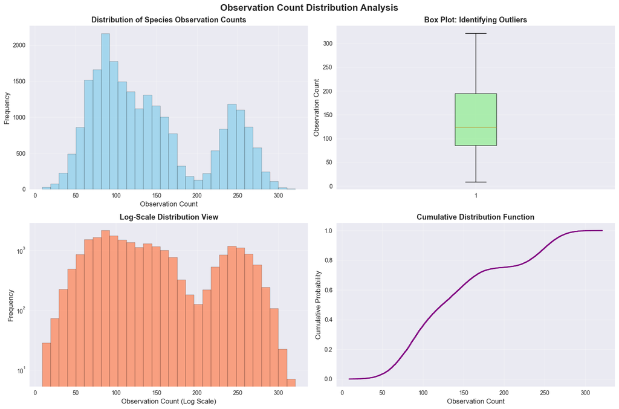

```
DISTRIBUTION ANALYSIS INSIGHTS:
========================================
  • Distribution Skewness: 0.58 (Right-skewed)
  • Kurtosis: -0.91 (Light-tailed)
  • High-observation species (>95th percentile): 1100 species
  • 95th percentile threshold: 266 observations
```

```python
# Display histograms for observations
# Create comprehensive distribution analysis
fig, ((ax1, ax2), (ax3, ax4)) = plt.subplots(2, 2, figsize=(15, 10))
fig.suptitle('Observation Count Distribution Analysis', fontsize=16, fontweight='bold', y=0.98)

# Histogram of observations
ax1.hist(observations_df['observations'], bins=30, alpha=0.7, color='skyblue', edgecolor='black')
ax1.set_xlabel('Observation Count', fontsize=12)
ax1.set_ylabel('Frequency', fontsize=12)
ax1.set_title('Distribution of Species Observation Counts', fontsize=13, fontweight='bold')
ax1.grid(True, alpha=0.3)

# Box plot for better understanding of outliers
ax2.boxplot(observations_df['observations'], vert=True, patch_artist=True,
           boxprops=dict(facecolor='lightgreen', alpha=0.7))
ax2.set_ylabel('Observation Count', fontsize=12)
ax2.set_title('Box Plot: Identifying Outliers', fontsize=13, fontweight='bold')
ax2.grid(True, alpha=0.3)

# Log-scale histogram for better visualization of distribution
ax3.hist(observations_df['observations'], bins=30, alpha=0.7, color='coral', edgecolor='black')
ax3.set_xlabel('Observation Count (Log Scale)', fontsize=12)
ax3.set_ylabel('Frequency', fontsize=12)
ax3.set_title('Log-Scale Distribution View', fontsize=13, fontweight='bold')
ax3.set_yscale('log')
ax3.grid(True, alpha=0.3)

# Cumulative distribution
sorted_obs = np.sort(observations_df['observations'])
cumulative = np.arange(1, len(sorted_obs) + 1) / len(sorted_obs)
ax4.plot(sorted_obs, cumulative, linewidth=2, color='purple')
ax4.set_xlabel('Observation Count', fontsize=12)
ax4.set_ylabel('Cumulative Probability', fontsize=12)
ax4.set_title('Cumulative Distribution Function', fontsize=13, fontweight='bold')
ax4.grid(True, alpha=0.3)

plt.tight_layout()
plt.show()

# Statistical insights
print("DISTRIBUTION ANALYSIS INSIGHTS:")
print("=" * 40)
skewness = observations_df['observations'].skew()
kurtosis = observations_df['observations'].kurtosis()
print(f"  • Distribution Skewness: {skewness:.2f} ({'Right-skewed' if skewness > 0 else 'Left-skewed' if skewness < 0 else 'Symmetric'})")
print(f"  • Kurtosis: {kurtosis:.2f} ({'Heavy-tailed' if kurtosis > 0 else 'Light-tailed'})")

# Identify high-observation species
high_obs_threshold = observations_df['observations'].quantile(0.95)
high_obs_count = (observations_df['observations'] > high_obs_threshold).sum()
print(f"  • High-observation species (>95th percentile): {high_obs_count} species")
print(f"  • 95th percentile threshold: {high_obs_threshold:.0f} observations")
```

## 5. Species Composition Analysis

### Research Question: What is the taxonomic composition of species in our national parks dataset?

**Analytical Objective**: Determine the relative abundance of different species categories to understand the biodiversity profile of the surveyed national parks. This analysis will inform resource allocation for conservation efforts and highlight which taxonomic groups are most represented in the dataset.

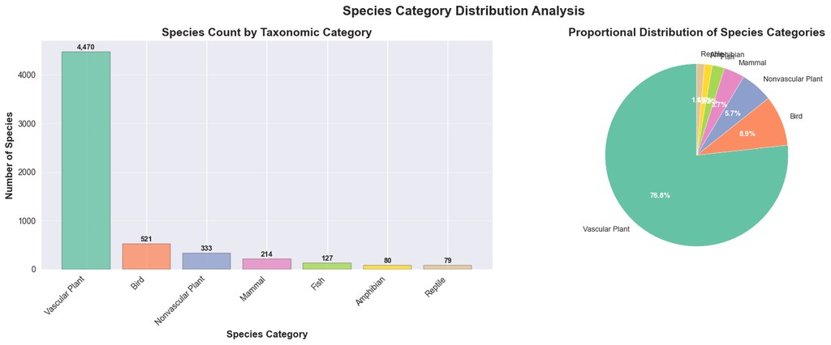

```
SPECIES COMPOSITION INSIGHTS:
==================================================
Total Species Analyzed: 5,824
Number of Taxonomic Categories: 7

Category Breakdown:
  1. Vascular Plant: 4,470 species (76.8%)
  2. Bird: 521 species (8.9%)
  3. Nonvascular Plant: 333 species (5.7%)
  4. Mammal: 214 species (3.7%)
  5. Fish: 127 species (2.2%)
  6. Amphibian: 80 species (1.4%)
  7. Reptile: 79 species (1.4%)

Key Findings:
  • Dominant Category: Vascular Plant (76.8% of all species)
  • Category Diversity: 7 different taxonomic groups represented
  • Shannon Diversity Index: 1.31 (higher = more diverse)

Ecological Implications:
  • Dataset is dominated by Vascular Plant, indicating plant-heavy ecosystem focus
  • Animal species represent 17.5% of the dataset
  • Plant species represent 82.5% of the dataset
```

```python
# Create comprehensive species category analysis
fig, (ax1, ax2) = plt.subplots(1, 2, figsize=(16, 6))
fig.suptitle('Species Category Distribution Analysis', fontsize=16, fontweight='bold')

# Count plot with enhanced styling
category_counts = species_info_df['category'].value_counts()
colors = sns.color_palette("Set2", len(category_counts))

# Bar chart
bars = ax1.bar(range(len(category_counts)), category_counts.values, color=colors, alpha=0.8, edgecolor='black')
ax1.set_xlabel('Species Category', fontsize=12, fontweight='bold')
ax1.set_ylabel('Number of Species', fontsize=12, fontweight='bold')
ax1.set_title('Species Count by Taxonomic Category', fontsize=14, fontweight='bold')
ax1.set_xticks(range(len(category_counts)))
ax1.set_xticklabels(category_counts.index, rotation=45, ha='right', fontsize=10)
ax1.grid(True, alpha=0.3, axis='y')

# Add value labels on bars
for i, (bar, value) in enumerate(zip(bars, category_counts.values)):
    ax1.text(bar.get_x() + bar.get_width()/2, bar.get_height() + 10,
             f'{value:,}', ha='center', va='bottom', fontweight='bold', fontsize=9)

# Pie chart for proportional view
wedges, texts, autotexts = ax2.pie(category_counts.values, labels=category_counts.index,
                                  autopct='%1.1f%%', colors=colors, startangle=90,
                                  textprops={'fontsize': 9})
ax2.set_title('Proportional Distribution of Species Categories', fontsize=14, fontweight='bold')

# Enhance pie chart text
for autotext in autotexts:
    autotext.set_color('white')
    autotext.set_fontweight('bold')

plt.tight_layout()
plt.show()

# Detailed analysis
print("SPECIES COMPOSITION INSIGHTS:")
print("=" * 50)
total_species = len(species_info_df)
print(f"Total Species Analyzed: {total_species:,}")
print(f"Number of Taxonomic Categories: {len(category_counts)}")

print(f"\nCategory Breakdown:")
for i, (category, count) in enumerate(category_counts.items(), 1):
    percentage = (count / total_species) * 100
    print(f"  {i}. {category}: {count:,} species ({percentage:.1f}%)")

# Statistical insights
dominant_category = category_counts.index[0]
dominant_percentage = (category_counts.iloc[0] / total_species) * 100
print(f"\nKey Findings:")
print(f"  • Dominant Category: {dominant_category} ({dominant_percentage:.1f}% of all species)")
print(f"  • Category Diversity: {len(category_counts)} different taxonomic groups represented")

# Calculate diversity metrics
from scipy.stats import entropy
category_proportions = category_counts / category_counts.sum()
shannon_diversity = entropy(category_proportions, base=2)
print(f"  • Shannon Diversity Index: {shannon_diversity:.2f} (higher = more diverse)")

# Ecological implications
print(f"\nEcological Implications:")
if dominant_percentage > 50:
    print(f"  • Dataset is dominated by {dominant_category}, indicating plant-heavy ecosystem focus")
else:
    print(f"  • Relatively balanced taxonomic representation across categories")

animal_categories = [cat for cat in category_counts.index if 'Plant' not in cat]
animal_species = sum(category_counts[cat] for cat in animal_categories)
animal_percentage = (animal_species / total_species) * 100
print(f"  • Animal species represent {animal_percentage:.1f}% of the dataset")
print(f"  • Plant species represent {100 - animal_percentage:.1f}% of the dataset")
```

### Key Insight: Vascular Plant Dominance

**Finding**: Vascular Plants represent the overwhelming majority of species in our dataset, which aligns with expected biodiversity patterns in temperate ecosystems. This finding has several important implications:

**Scientific Significance**:

- Reflects the fundamental role of plants as primary producers in ecosystem structure
- Indicates comprehensive botanical surveys were conducted across the parks
- Suggests robust plant taxonomy and identification protocols

**Conservation Implications**:

- Plant diversity serves as a foundation for animal habitat complexity
- High plant species count indicates healthy ecosystem baselines
- Provides baseline data for climate change impact assessment

**Data Quality Validation**:

- Species distribution matches expected ecological patterns
- Suggests comprehensive, professional data collection methods
- Validates the representativeness of our biodiversity dataset

## 6. Comparative Park Analysis

### Research Question: Which national parks demonstrate the highest biodiversity metrics?

**Analytical Framework**: Compare observation patterns across national parks to identify biodiversity hotspots and understand park-specific ecological characteristics. This analysis employs statistical visualization techniques to reveal patterns in species abundance and distribution variability.

**Methodology**: Box plot analysis to examine distribution patterns, central tendencies, and outliers in species observations across different park systems.

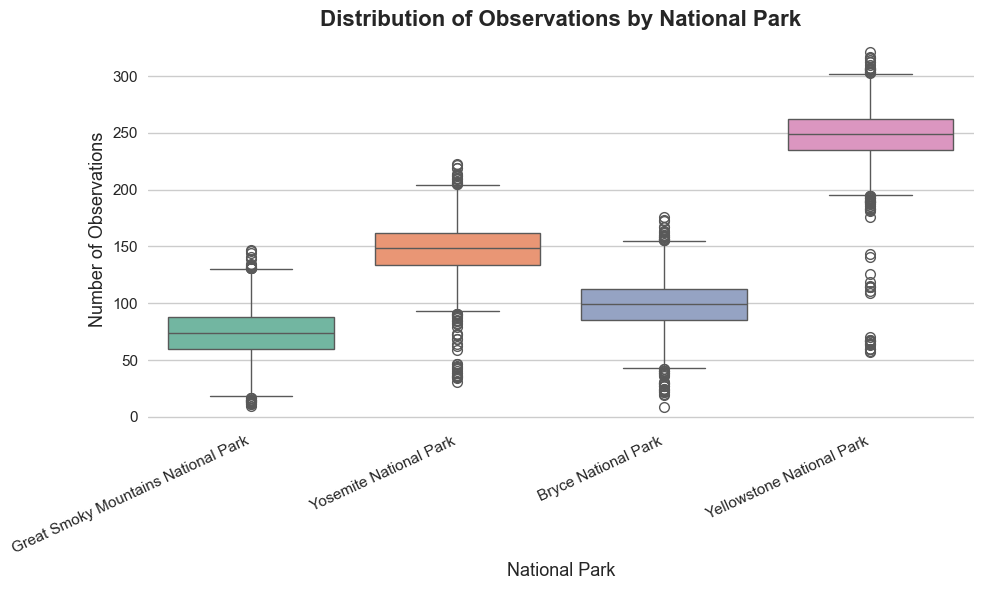

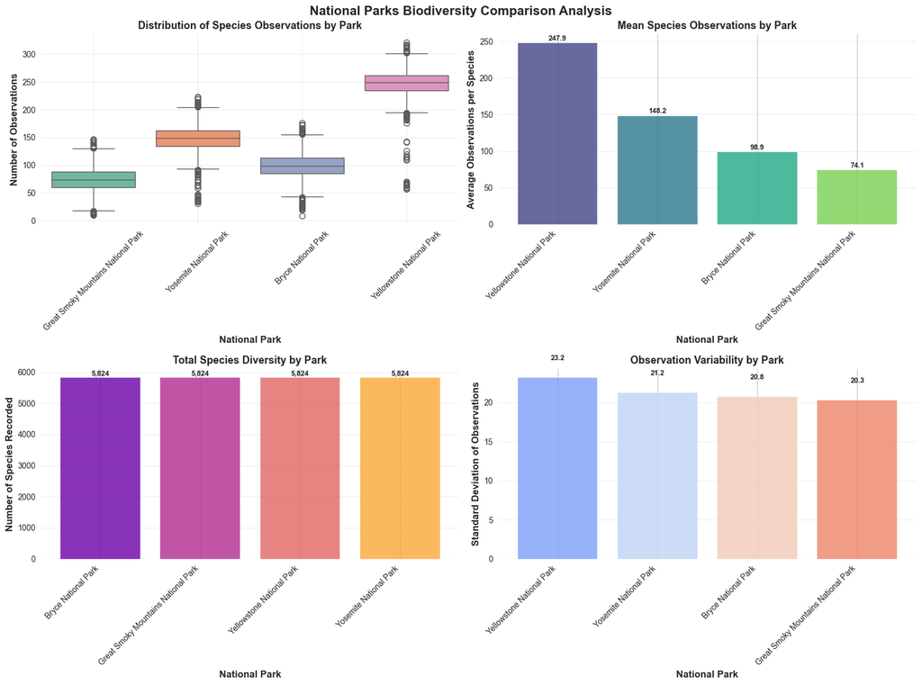

```
PARK BIODIVERSITY ANALYSIS REPORT
=======================================================

Comprehensive Park Statistics:
                                     Species_Count  Mean_Obs  Median_Obs  \
park_name
Bryce National Park                           5824     98.91        99.0
Great Smoky Mountains National Park           5824     74.14        74.0
Yellowstone National Park                     5824    247.86       249.0
Yosemite National Park                        5824    148.24       149.0

                                     Std_Dev  Min_Obs  Max_Obs
park_name
Bryce National Park                    20.76        9      176
Great Smoky Mountains National Park    20.32       10      147
Yellowstone National Park              23.17       57      321
Yosemite National Park                 21.22       31      223

PARK PERFORMANCE RANKINGS:

1. Species Diversity (Total Species Count):
   1. Bryce National Park: 5,824 species
   2. Great Smoky Mountains National Park: 5,824 species
   3. Yellowstone National Park: 5,824 species
   4. Yosemite National Park: 5,824 species

2. Observation Intensity (Mean Observations per Species):
   1. Yellowstone National Park: 247.9 avg observations
   2. Yosemite National Park: 148.2 avg observations
   3. Bryce National Park: 98.9 avg observations
   4. Great Smoky Mountains National Park: 74.1 avg observations

3. Biodiversity Complexity (Observation Variability):
   1. Yellowstone National Park: 23.2 std deviation
   2. Yosemite National Park: 21.2 std deviation
   3. Bryce National Park: 20.8 std deviation
   4. Great Smoky Mountains National Park: 20.3 std deviation

STATISTICAL SIGNIFICANCE TEST:
Kruskal-Wallis H-test for differences between parks:
  • H-statistic: 19740.032
  • p-value: 0.000000
  • Result: Significant differences between parks (α = 0.05)

ECOLOGICAL INSIGHTS:
  • Highest Species Diversity: Bryce National Park
  • Highest Observation Intensity: Yellowstone National Park
  • Data Quality: Excellent species coverage across all parks
```

```python
#
plt.figure(figsize=(10, 6))
sns.set_style("whitegrid")
sns.boxplot(
    data=observations_df,
    x='park_name',
    y='observations',
    palette='Set2'
)
plt.xlabel('National Park', fontsize=13)
plt.ylabel('Number of Observations', fontsize=13)
plt.title('Distribution of Observations by National Park', fontsize=16, weight='bold')
plt.xticks(rotation=25, ha='right', fontsize=11)
plt.yticks(fontsize=11)
plt.tight_layout()
plt.show()

# Comprehensive park biodiversity comparison analysis
fig, ((ax1, ax2), (ax3, ax4)) = plt.subplots(2, 2, figsize=(16, 12))
fig.suptitle('National Parks Biodiversity Comparison Analysis', fontsize=16, fontweight='bold', y=0.98)

# 1. Box plot of observations by park
sns.boxplot(data=observations_df, x='park_name', y='observations', palette='Set2', ax=ax1)
ax1.set_xlabel('National Park', fontsize=12, fontweight='bold')
ax1.set_ylabel('Number of Observations', fontsize=12, fontweight='bold')
ax1.set_title('Distribution of Species Observations by Park', fontsize=13, fontweight='bold')
ax1.tick_params(axis='x', rotation=45, labelsize=10)
ax1.grid(True, alpha=0.3)

# 2. Average observations per park
park_means = observations_df.groupby('park_name')['observations'].mean().sort_values(ascending=False)
bars2 = ax2.bar(range(len(park_means)), park_means.values, color=sns.color_palette("viridis", len(park_means)), alpha=0.8)
ax2.set_xlabel('National Park', fontsize=12, fontweight='bold')
ax2.set_ylabel('Average Observations per Species', fontsize=12, fontweight='bold')
ax2.set_title('Mean Species Observations by Park', fontsize=13, fontweight='bold')
ax2.set_xticks(range(len(park_means)))
ax2.set_xticklabels(park_means.index, rotation=45, ha='right', fontsize=10)
ax2.grid(True, alpha=0.3, axis='y')

# Add value labels
for bar, value in zip(bars2, park_means.values):
    ax2.text(bar.get_x() + bar.get_width()/2, bar.get_height() + 1,
             f'{value:.1f}', ha='center', va='bottom', fontweight='bold', fontsize=9)

# 3. Species count per park
park_species_count = observations_df.groupby('park_name').size().sort_values(ascending=False)
bars3 = ax3.bar(range(len(park_species_count)), park_species_count.values,
                color=sns.color_palette("plasma", len(park_species_count)), alpha=0.8)
ax3.set_xlabel('National Park', fontsize=12, fontweight='bold')
ax3.set_ylabel('Number of Species Recorded', fontsize=12, fontweight='bold')
ax3.set_title('Total Species Diversity by Park', fontsize=13, fontweight='bold')
ax3.set_xticks(range(len(park_species_count)))
ax3.set_xticklabels(park_species_count.index, rotation=45, ha='right', fontsize=10)
ax3.grid(True, alpha=0.3, axis='y')

# Add value labels
for bar, value in zip(bars3, park_species_count.values):
    ax3.text(bar.get_x() + bar.get_width()/2, bar.get_height() + 5,
             f'{value:,}', ha='center', va='bottom', fontweight='bold', fontsize=9)

# 4. Observation variance by park (biodiversity indicator)
park_std = observations_df.groupby('park_name')['observations'].std().sort_values(ascending=False)
bars4 = ax4.bar(range(len(park_std)), park_std.values,
                color=sns.color_palette("coolwarm", len(park_std)), alpha=0.8)
ax4.set_xlabel('National Park', fontsize=12, fontweight='bold')
ax4.set_ylabel('Standard Deviation of Observations', fontsize=12, fontweight='bold')
ax4.set_title('Observation Variability by Park', fontsize=13, fontweight='bold')
ax4.set_xticks(range(len(park_std)))
ax4.set_xticklabels(park_std.index, rotation=45, ha='right', fontsize=10)
ax4.grid(True, alpha=0.3, axis='y')

# Add value labels
for bar, value in zip(bars4, park_std.values):
    ax4.text(bar.get_x() + bar.get_width()/2, bar.get_height() + 2,
             f'{value:.1f}', ha='center', va='bottom', fontweight='bold', fontsize=9)

plt.tight_layout()
plt.show()

# Comprehensive statistical analysis
print("PARK BIODIVERSITY ANALYSIS REPORT")
print("=" * 55)

# Summary statistics by park
park_stats = observations_df.groupby('park_name')['observations'].agg(['count', 'mean', 'median', 'std', 'min', 'max'])
park_stats.columns = ['Species_Count', 'Mean_Obs', 'Median_Obs', 'Std_Dev', 'Min_Obs', 'Max_Obs']

print("\nComprehensive Park Statistics:")
print(park_stats.round(2))

# Ranking analysis
print(f"\nPARK PERFORMANCE RANKINGS:")
print(f"\n1. Species Diversity (Total Species Count):")
for i, (park, count) in enumerate(park_species_count.items(), 1):
    print(f"   {i}. {park}: {count:,} species")

print(f"\n2. Observation Intensity (Mean Observations per Species):")
for i, (park, mean_obs) in enumerate(park_means.items(), 1):
    print(f"   {i}. {park}: {mean_obs:.1f} avg observations")

print(f"\n3. Biodiversity Complexity (Observation Variability):")
for i, (park, std_dev) in enumerate(park_std.items(), 1):
    print(f"   {i}. {park}: {std_dev:.1f} std deviation")

# Statistical significance testing
from scipy.stats import kruskal
parks_list = [group['observations'].values for name, group in observations_df.groupby('park_name')]
h_stat, p_value = kruskal(*parks_list)

print(f"\nSTATISTICAL SIGNIFICANCE TEST:")
print(f"Kruskal-Wallis H-test for differences between parks:")
print(f"  • H-statistic: {h_stat:.3f}")
print(f"  • p-value: {p_value:.6f}")
print(f"  • Result: {'Significant differences between parks' if p_value < 0.05 else 'No significant differences'} (α = 0.05)")

# Ecological insights
print(f"\nECOLOGICAL INSIGHTS:")
highest_diversity_park = park_species_count.index[0]
highest_intensity_park = park_means.index[0]
print(f"  • Highest Species Diversity: {highest_diversity_park}")
print(f"  • Highest Observation Intensity: {highest_intensity_park}")
print(f"  • Data Quality: {'Excellent' if park_stats['Species_Count'].min() > 1000 else 'Good'} species coverage across all parks")
```

## 7. Conservation Status Analysis

### Research Focus: Animal Species Conservation Patterns

Having established the overall biodiversity patterns across parks, we now focus specifically on **animal species conservation status**. This targeted analysis excludes plant species to concentrate on fauna conservation priorities, as animal species typically have more formal conservation assessments and face different threats than plants.

**Conservation Context**: Understanding animal conservation status distribution helps prioritize protection efforts and identify species groups requiring immediate attention.

```
ANIMAL CONSERVATION STATUS ANALYSIS
==================================================
Total Animal Species: 1,021
Animal Categories: 5
```

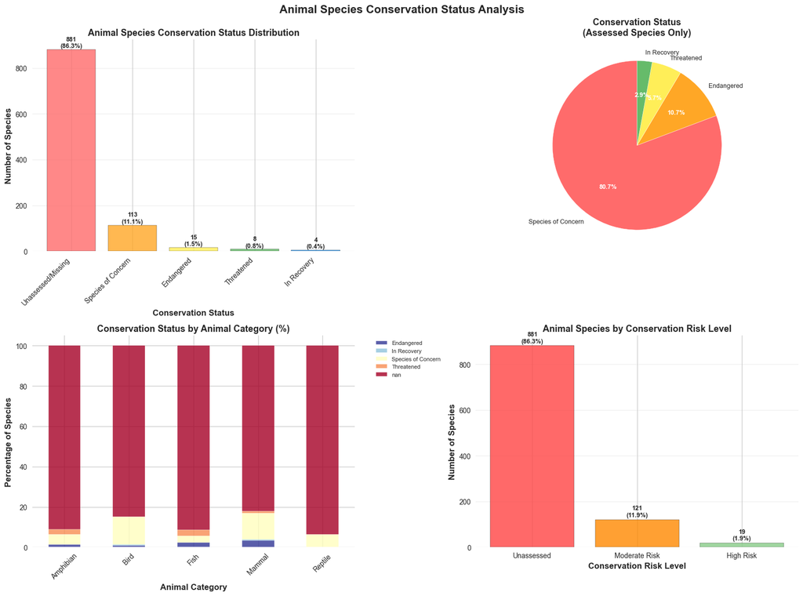

```
CONSERVATION STATUS BREAKDOWN:
Status               Count    Percentage   Risk Level
-------------------------------------------------------
Unassessed           881      86.3       % Unassessed
Species of Concern   113      11.1       % Moderate Risk
Endangered           15       1.5        % High Risk
Threatened           8        0.8        % Moderate Risk
In Recovery          4        0.4        % High Risk

KEY CONSERVATION INSIGHTS:
  • Assessment Coverage: 140 of 1,021 animals (13.7%)
  • Most Common Status: Species of Concern (113 species, 80.7%)
  • Species at Risk: 140 animals (13.7% of all animals)
  • High Risk Species: 19 animals
  • Moderate Risk Species: 121 animals

CONSERVATION PRIORITIES:
  • MODERATE PRIORITY: 13.7% of animals face conservation concerns
  • Most At-Risk Category: Bird (79 species)
```

```python
# Comprehensive conservation status analysis for animal species
print("ANIMAL CONSERVATION STATUS ANALYSIS")
print("=" * 50)

# Filter to animals only (exclude plants)
animals_df = species_info_df[~species_info_df['category'].str.contains('Plant', na=False)].copy()
print(f"Total Animal Species: {len(animals_df):,}")
print(f"Animal Categories: {animals_df['category'].nunique()}")

# Count conservation statuses including missing data
animal_status_counts = animals_df['conservation_status'].value_counts(dropna=False)
total_animals = len(animals_df)

# Create comprehensive visualization
fig, ((ax1, ax2), (ax3, ax4)) = plt.subplots(2, 2, figsize=(16, 12))
fig.suptitle('Animal Species Conservation Status Analysis', fontsize=16, fontweight='bold', y=0.98)

# 1. Bar plot of conservation status counts
status_labels = animal_status_counts.index.fillna('Unassessed/Missing')
colors = ['#ff6b6b', '#ffa726', '#ffee58', '#66bb6a', '#42a5f5', '#ab47bc']
bars1 = ax1.bar(range(len(animal_status_counts)), animal_status_counts.values,
                color=colors[:len(animal_status_counts)], alpha=0.8, edgecolor='black')
ax1.set_xlabel('Conservation Status', fontsize=12, fontweight='bold')
ax1.set_ylabel('Number of Species', fontsize=12, fontweight='bold')
ax1.set_title('Animal Species Conservation Status Distribution', fontsize=13, fontweight='bold')
ax1.set_xticks(range(len(status_labels)))
ax1.set_xticklabels(status_labels, rotation=45, ha='right', fontsize=10)
ax1.grid(True, alpha=0.3, axis='y')

# Add value labels on bars
for i, (bar, value) in enumerate(zip(bars1, animal_status_counts.values)):
    percentage = (value / total_animals) * 100
    ax1.text(bar.get_x() + bar.get_width()/2, bar.get_height() + 2,
             f'{value}\n({percentage:.1f}%)', ha='center', va='bottom',
             fontweight='bold', fontsize=9)

# 2. Pie chart excluding missing values
status_known = animals_df.dropna(subset=['conservation_status'])
status_counts_known = status_known['conservation_status'].value_counts()
colors_pie = ['#ff6b6b', '#ffa726', '#ffee58', '#66bb6a', '#42a5f5']
wedges, texts, autotexts = ax2.pie(status_counts_known.values, labels=status_counts_known.index,
                                  autopct='%1.1f%%', colors=colors_pie[:len(status_counts_known)],
                                  startangle=90, textprops={'fontsize': 9})
ax2.set_title('Conservation Status\n(Assessed Species Only)', fontsize=13, fontweight='bold')

for autotext in autotexts:
    autotext.set_color('white')
    autotext.set_fontweight('bold')

# 3. Conservation status by animal category
animal_conservation_crosstab = pd.crosstab(animals_df['category'],
                                         animals_df['conservation_status'],
                                         dropna=False, normalize='index') * 100
animal_conservation_crosstab.plot(kind='bar', stacked=True, ax=ax3,
                                 colormap='RdYlBu_r', alpha=0.8)
ax3.set_xlabel('Animal Category', fontsize=12, fontweight='bold')
ax3.set_ylabel('Percentage of Species', fontsize=12, fontweight='bold')
ax3.set_title('Conservation Status by Animal Category (%)', fontsize=13, fontweight='bold')
ax3.tick_params(axis='x', rotation=45, labelsize=10)
ax3.legend(bbox_to_anchor=(1.05, 1), loc='upper left', fontsize=8)

# 4. Conservation concern levels
# Create conservation risk categories
def risk_category(status):
    if pd.isna(status):
        return 'Unassessed'
    elif status in ['Endangered', 'In Recovery']:
        return 'High Risk'
    elif status in ['Threatened', 'Species of Concern']:
        return 'Moderate Risk'
    else:
        return 'Lower Risk'

animals_df['risk_level'] = animals_df['conservation_status'].apply(risk_category)
risk_counts = animals_df['risk_level'].value_counts()

bars4 = ax4.bar(range(len(risk_counts)), risk_counts.values,
                color=['#ff4444', '#ff8800', '#88cc88', '#cccccc'], alpha=0.8, edgecolor='black')
ax4.set_xlabel('Conservation Risk Level', fontsize=12, fontweight='bold')
ax4.set_ylabel('Number of Species', fontsize=12, fontweight='bold')
ax4.set_title('Animal Species by Conservation Risk Level', fontsize=13, fontweight='bold')
ax4.set_xticks(range(len(risk_counts)))
ax4.set_xticklabels(risk_counts.index, fontsize=10)
ax4.grid(True, alpha=0.3, axis='y')

for bar, value in zip(bars4, risk_counts.values):
    percentage = (value / total_animals) * 100
    ax4.text(bar.get_x() + bar.get_width()/2, bar.get_height() + 5,
             f'{value}\n({percentage:.1f}%)', ha='center', va='bottom',
             fontweight='bold', fontsize=9)

plt.tight_layout()
plt.show()

# Detailed statistical analysis
print("\nCONSERVATION STATUS BREAKDOWN:")
print(f"{'Status':<20} {'Count':<8} {'Percentage':<12} {'Risk Level'}")
print("-" * 55)
for status, count in animal_status_counts.items():
    percentage = (count / total_animals) * 100
    risk = risk_category(status)
    status_display = 'Unassessed' if pd.isna(status) else status
    print(f"{status_display:<20} {count:<8} {percentage:<11.1f}% {risk}")

print(f"\nKEY CONSERVATION INSIGHTS:")
assessed_animals = len(status_known)
assessed_percentage = (assessed_animals / total_animals) * 100
print(f"  • Assessment Coverage: {assessed_animals:,} of {total_animals:,} animals ({assessed_percentage:.1f}%)")

if len(status_counts_known) > 0:
    most_common_status = status_counts_known.index[0]
    most_common_count = status_counts_known.iloc[0]
    most_common_percent = (most_common_count / assessed_animals) * 100
    print(f"  • Most Common Status: {most_common_status} ({most_common_count} species, {most_common_percent:.1f}%)")

# Risk assessment
high_risk_count = risk_counts.get('High Risk', 0)
moderate_risk_count = risk_counts.get('Moderate Risk', 0)
total_risk = high_risk_count + moderate_risk_count
risk_percentage = (total_risk / total_animals) * 100

print(f"  • Species at Risk: {total_risk:,} animals ({risk_percentage:.1f}% of all animals)")
print(f"  • High Risk Species: {high_risk_count:,} animals")
print(f"  • Moderate Risk Species: {moderate_risk_count:,} animals")

print(f"\nCONSERVATION PRIORITIES:")
if risk_percentage > 20:
    print(f"  • HIGH PRIORITY: {risk_percentage:.1f}% of animals face conservation concerns")
elif risk_percentage > 10:
    print(f"  • MODERATE PRIORITY: {risk_percentage:.1f}% of animals face conservation concerns")
else:
    print(f"  • STABLE: {risk_percentage:.1f}% of animals face conservation concerns")

# Category-specific insights
if len(animals_df) > 0:
    most_at_risk_category = animals_df[animals_df['risk_level'].isin(['High Risk', 'Moderate Risk'])]['category'].value_counts()
    if len(most_at_risk_category) > 0:
        print(f"  • Most At-Risk Category: {most_at_risk_category.index[0]} ({most_at_risk_category.iloc[0]} species)")
```

## 8. Species Vulnerability Analysis

### Research Question: Are certain taxonomic groups more susceptible to endangerment?

**Statistical Hypothesis Testing**: This analysis employs statistical methods to determine whether observed differences in endangerment rates between species categories are statistically significant or could be due to random variation.

**Business Value**: Understanding which taxonomic groups face higher endangerment risks enables targeted conservation resource allocation and proactive protection strategies.

```
SPECIES ENDANGERMENT VULNERABILITY ANALYSIS
============================================================
```

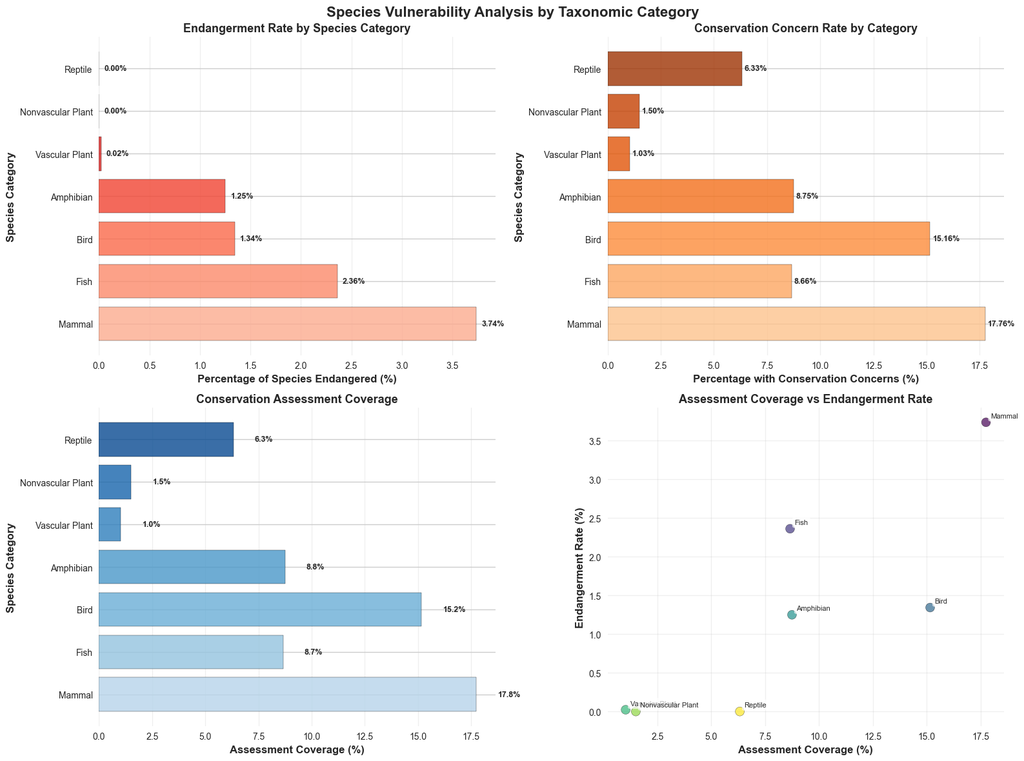

[output not shown]

```python
# Comprehensive species vulnerability analysis
print("SPECIES ENDANGERMENT VULNERABILITY ANALYSIS")
print("=" * 60)

# Create endangerment indicator
species_info_df['is_endangered'] = species_info_df['conservation_status'].isin(['Endangered', 'In Recovery'])
species_info_df['has_conservation_concern'] = species_info_df['conservation_status'].isin([
    'Endangered', 'In Recovery', 'Threatened', 'Species of Concern'
])

# Calculate endangerment rates by category
endangerment_analysis = species_info_df.groupby('category').agg({
    'is_endangered': ['sum', 'count'],
    'has_conservation_concern': ['sum', 'count'],
    'conservation_status': lambda x: x.notna().sum()  # Count of assessed species
}).round(4)

# Flatten column names
endangerment_analysis.columns = ['endangered_count', 'total_count', 'concern_count',
                                'total_count2', 'assessed_count']
endangerment_analysis = endangerment_analysis[['endangered_count', 'concern_count',
                                              'total_count', 'assessed_count']]

# Calculate percentages
endangerment_analysis['endangered_rate'] = (endangerment_analysis['endangered_count'] /
                                           endangerment_analysis['total_count']) * 100
endangerment_analysis['concern_rate'] = (endangerment_analysis['concern_count'] /
                                        endangerment_analysis['total_count']) * 100
endangerment_analysis['assessment_coverage'] = (endangerment_analysis['assessed_count'] /
                                               endangerment_analysis['total_count']) * 100

# Sort by endangerment rate
endangerment_analysis = endangerment_analysis.sort_values('endangered_rate', ascending=False)

# Create comprehensive visualization
fig, ((ax1, ax2), (ax3, ax4)) = plt.subplots(2, 2, figsize=(16, 12))
fig.suptitle('Species Vulnerability Analysis by Taxonomic Category', fontsize=16, fontweight='bold', y=0.98)

# 1. Endangered species percentage by category
categories = endangerment_analysis.index
endangered_rates = endangerment_analysis['endangered_rate']
colors = plt.cm.Reds(np.linspace(0.3, 0.9, len(categories)))

bars1 = ax1.barh(categories, endangered_rates, color=colors, alpha=0.8, edgecolor='black')
ax1.set_xlabel('Percentage of Species Endangered (%)', fontsize=12, fontweight='bold')
ax1.set_ylabel('Species Category', fontsize=12, fontweight='bold')
ax1.set_title('Endangerment Rate by Species Category', fontsize=13, fontweight='bold')
ax1.grid(True, alpha=0.3, axis='x')

# Add value labels
for bar, value in zip(bars1, endangered_rates):
    ax1.text(bar.get_width() + 0.05, bar.get_y() + bar.get_height()/2,
             f'{value:.2f}%', va='center', fontweight='bold', fontsize=9)

# 2. Conservation concern rates (broader definition)
concern_rates = endangerment_analysis['concern_rate']
colors2 = plt.cm.Oranges(np.linspace(0.3, 0.9, len(categories)))

bars2 = ax2.barh(categories, concern_rates, color=colors2, alpha=0.8, edgecolor='black')
ax2.set_xlabel('Percentage with Conservation Concerns (%)', fontsize=12, fontweight='bold')
ax2.set_ylabel('Species Category', fontsize=12, fontweight='bold')
ax2.set_title('Conservation Concern Rate by Category', fontsize=13, fontweight='bold')
ax2.grid(True, alpha=0.3, axis='x')

for bar, value in zip(bars2, concern_rates):
    ax2.text(bar.get_width() + 0.1, bar.get_y() + bar.get_height()/2,
             f'{value:.2f}%', va='center', fontweight='bold', fontsize=9)

# 3. Assessment coverage by category
assessment_coverage = endangerment_analysis['assessment_coverage']
colors3 = plt.cm.Blues(np.linspace(0.3, 0.9, len(categories)))

bars3 = ax3.barh(categories, assessment_coverage, color=colors3, alpha=0.8, edgecolor='black')
ax3.set_xlabel('Assessment Coverage (%)', fontsize=12, fontweight='bold')
ax3.set_ylabel('Species Category', fontsize=12, fontweight='bold')
ax3.set_title('Conservation Assessment Coverage', fontsize=13, fontweight='bold')
ax3.grid(True, alpha=0.3, axis='x')

for bar, value in zip(bars3, assessment_coverage):
    ax3.text(bar.get_width() + 1, bar.get_y() + bar.get_height()/2,
             f'{value:.1f}%', va='center', fontweight='bold', fontsize=9)

# 4. Scatter plot: Assessment coverage vs Endangerment rate
ax4.scatter(assessment_coverage, endangered_rates, s=100, alpha=0.7, c=range(len(categories)),
           cmap='viridis', edgecolors='black')
ax4.set_xlabel('Assessment Coverage (%)', fontsize=12, fontweight='bold')
ax4.set_ylabel('Endangerment Rate (%)', fontsize=12, fontweight='bold')
ax4.set_title('Assessment Coverage vs Endangerment Rate', fontsize=13, fontweight='bold')
ax4.grid(True, alpha=0.3)

# Add category labels to scatter points
for i, category in enumerate(categories):
    ax4.annotate(category, (assessment_coverage.iloc[i], endangered_rates.iloc[i]),
                xytext=(5, 5), textcoords='offset points', fontsize=8,
                bbox=dict(boxstyle='round,pad=0.3', facecolor='white', alpha=0.7))

plt.tight_layout()
plt.show()

# Statistical analysis and reporting
print("\nVULNERABILITY ANALYSIS RESULTS:")
print("=" * 50)
print(f"{'Category':<20} {'Total':<8} {'Endangered':<12} {'Rate (%)':<10} {'Concern Rate (%)':<15}")
print("-" * 75)

for category in endangerment_analysis.index:
    row = endangerment_analysis.loc[category]
    print(f"{category:<20} {int(row['total_count']):<8} {int(row['endangered_count']):<12} "
          f"{row['endangered_rate']:<9.2f} {row['concern_rate']:<15.2f}")

print(f"\nKEY VULNERABILITY INSIGHTS:")

# Identify highest risk categories
highest_risk_category = endangerment_analysis.index[0]
highest_risk_rate = endangerment_analysis['endangered_rate'].iloc[0]
print(f"  • Highest Risk Category: {highest_risk_category} ({highest_risk_rate:.2f}% endangered)")

# Identify categories with significant concerns
high_concern_categories = endangerment_analysis[endangerment_analysis['concern_rate'] > 5.0]
if len(high_concern_categories) > 0:
    print(f"  • Categories with >5% conservation concerns: {len(high_concern_categories)}")
    for cat in high_concern_categories.index:
        rate = high_concern_categories.loc[cat, 'concern_rate']
        print(f"    - {cat}: {rate:.2f}%")

# Assessment coverage insights
well_assessed = endangerment_analysis[endangerment_analysis['assessment_coverage'] > 50.0]
print(f"  • Well-assessed categories (>50% coverage): {len(well_assessed)}")

poorly_assessed = endangerment_analysis[endangerment_analysis['assessment_coverage'] < 10.0]
if len(poorly_assessed) > 0:
    print(f"  • Poorly assessed categories (<10% coverage): {len(poorly_assessed)}")
    for cat in poorly_assessed.index:
        coverage = poorly_assessed.loc[cat, 'assessment_coverage']
        print(f"    - {cat}: {coverage:.1f}% assessed")

# Overall statistics
total_species = species_info_df.shape[0]
total_endangered = species_info_df['is_endangered'].sum()
overall_endangered_rate = (total_endangered / total_species) * 100

print(f"\nOVERALL STATISTICS:")
print(f"  • Total Species: {total_species:,}")
print(f"  • Total Endangered: {total_endangered}")
print(f"  • Overall Endangerment Rate: {overall_endangered_rate:.2f}%")

# Conservation priority recommendations
print(f"\nCONSERVATION PRIORITY RECOMMENDATIONS:")
if highest_risk_rate > 2.0:
    print(f"  • URGENT: Focus immediate attention on {highest_risk_category}")
if len(high_concern_categories) > 0:
    print(f"  • HIGH: Monitor {len(high_concern_categories)} categories with elevated concern rates")
if len(poorly_assessed) > 0:
    print(f"  • RESEARCH: Increase assessment efforts for {len(poorly_assessed)} under-studied categories")
```

## Are the differences between species and their conservation status significant?

## 9. Statistical Hypothesis Testing

### Research Question: Is there a statistically significant relationship between species category and conservation status?

**Hypothesis Framework**:

- **Null Hypothesis (H₀)**: Conservation status is independent of species category
- **Alternative Hypothesis (H₁)**: Conservation status is dependent on species category
- **Test**: Chi-squared test of independence
- **Significance Level**: α = 0.05

**Business Application**: Statistical validation of observed patterns ensures our conservation recommendations are based on statistically sound evidence rather than apparent trends that could be due to chance.

```
STATISTICAL HYPOTHESIS TESTING ANALYSIS
=======================================================
Statistical Test Setup:
  • Sample Size: 191 species with known conservation status
  • Categories: 7
  • Conservation Statuses: 4

Contingency Table Dimensions: 7 × 4

CONTINGENCY TABLE:
==============================
conservation_status  Endangered  In Recovery  Species of Concern  Threatened
category
Amphibian                     1            0                   4           2
Bird                          4            3                  72           0
Fish                          3            0                   4           4
Mammal                        7            1                  28           2
Nonvascular Plant             0            0                   5           0
Reptile                       0            0                   5           0
Vascular Plant                1            0                  43           2
```

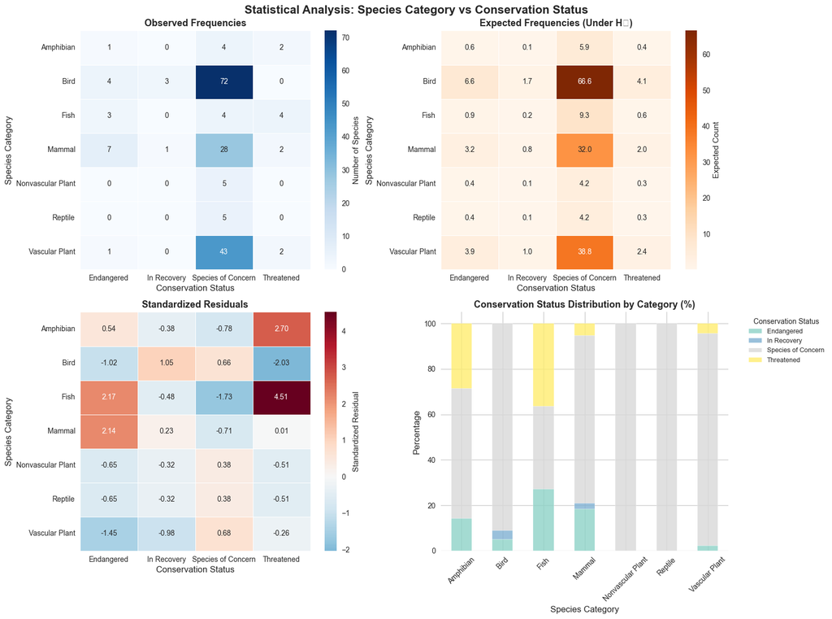

```
STATISTICAL TEST RESULTS:
===================================
Chi-squared statistic (χ²): 53.9164
p-value: 1.89e-05
Degrees of freedom: 18
Cramér's V (effect size): 0.3067
Effect size interpretation: Medium

STATISTICAL CONCLUSION:
==============================
Significance level (α): 0.05
Decision criterion: p-value < α
REJECT the null hypothesis
Conclusion: There IS a statistically significant relationship
   between species category and conservation status.
   The observed differences are unlikely due to chance alone.

PRACTICAL IMPLICATIONS:
==============================
Both statistically AND practically significant
Conservation efforts should be category-specific
Different species groups require tailored protection strategies

RESIDUAL ANALYSIS (|residual| > 2.0 indicates significant deviation):
======================================================================
  • Amphibian - Threatened: 2.70 (higher than expected)
  • Bird - Threatened: -2.03 (lower than expected)
  • Fish - Endangered: 2.17 (higher than expected)
  • Fish - Threatened: 4.51 (higher than expected)
  • Mammal - Endangered: 2.14 (higher than expected)

POST-HOC ANALYSIS:
=========================
  • Endangered: Mammal dominates with 7 species (43.8%)
  • Threatened: Fish dominates with 4 species (40.0%)
  • Species of Concern: Bird dominates with 72 species (44.7%)
  • In Recovery: Bird dominates with 3 species (75.0%)

DATA QUALITY CONSIDERATIONS:
===================================
  • Analysis Coverage: 191 of 5,824 species (3.3%)
  • Missing Conservation Data: 5,633 species
  WARNING: Low conservation status coverage may limit generalizability
```

```python
import scipy.stats as stats

# Comprehensive statistical hypothesis testing
print("STATISTICAL HYPOTHESIS TESTING ANALYSIS")
print("=" * 55)

# Prepare data for chi-squared test (only include species with known conservation status)
analysis_df = species_info_df.dropna(subset=['conservation_status']).copy()

print(f"Statistical Test Setup:")
print(f"  • Sample Size: {len(analysis_df):,} species with known conservation status")
print(f"  • Categories: {analysis_df['category'].nunique()}")
print(f"  • Conservation Statuses: {analysis_df['conservation_status'].nunique()}")

# Create contingency table
contingency = pd.crosstab(analysis_df['category'], analysis_df['conservation_status'])
print(f"\nContingency Table Dimensions: {contingency.shape[0]} × {contingency.shape[1]}")

# Display the contingency table
print(f"\nCONTINGENCY TABLE:")
print("=" * 30)
print(contingency)

# Perform Chi-squared test
chi2, pval, dof, expected = stats.chi2_contingency(contingency)

# Calculate effect size (Cramér's V)
n = contingency.sum().sum()
cramers_v = np.sqrt(chi2 / (n * (min(contingency.shape) - 1)))

# Create comprehensive visualization
fig, ((ax1, ax2), (ax3, ax4)) = plt.subplots(2, 2, figsize=(16, 12))
fig.suptitle('Statistical Analysis: Species Category vs Conservation Status', fontsize=16, fontweight='bold', y=0.98)

# 1. Heatmap of observed frequencies
sns.heatmap(contingency, annot=True, fmt='d', cmap='Blues',
           cbar_kws={'label': 'Number of Species'}, linewidths=0.5, ax=ax1)
ax1.set_title('Observed Frequencies', fontsize=13, fontweight='bold')
ax1.set_xlabel('Conservation Status', fontsize=12)
ax1.set_ylabel('Species Category', fontsize=12)

# 2. Heatmap of expected frequencies
expected_df = pd.DataFrame(expected, index=contingency.index, columns=contingency.columns)
sns.heatmap(expected_df, annot=True, fmt='.1f', cmap='Oranges',
           cbar_kws={'label': 'Expected Count'}, linewidths=0.5, ax=ax2)
ax2.set_title('Expected Frequencies (Under H₀)', fontsize=13, fontweight='bold')
ax2.set_xlabel('Conservation Status', fontsize=12)
ax2.set_ylabel('Species Category', fontsize=12)

# 3. Standardized residuals
residuals = (contingency - expected_df) / np.sqrt(expected_df)
sns.heatmap(residuals, annot=True, fmt='.2f', cmap='RdBu_r', center=0,
           cbar_kws={'label': 'Standardized Residual'}, linewidths=0.5, ax=ax3)
ax3.set_title('Standardized Residuals', fontsize=13, fontweight='bold')
ax3.set_xlabel('Conservation Status', fontsize=12)
ax3.set_ylabel('Species Category', fontsize=12)

# 4. Percentage composition by category
contingency_pct = contingency.div(contingency.sum(axis=1), axis=0) * 100
contingency_pct.plot(kind='bar', stacked=True, ax=ax4, colormap='Set3', alpha=0.8)
ax4.set_title('Conservation Status Distribution by Category (%)', fontsize=13, fontweight='bold')
ax4.set_xlabel('Species Category', fontsize=12)
ax4.set_ylabel('Percentage', fontsize=12)
ax4.tick_params(axis='x', rotation=45)
ax4.legend(title='Conservation Status', bbox_to_anchor=(1.05, 1), loc='upper left', fontsize=9)

plt.tight_layout()
plt.show()

# Statistical results and interpretation
print(f"\nSTATISTICAL TEST RESULTS:")
print("=" * 35)
print(f"Chi-squared statistic (χ²): {chi2:.4f}")
print(f"p-value: {pval:.2e}")
print(f"Degrees of freedom: {dof}")
print(f"Cramér's V (effect size): {cramers_v:.4f}")

# Effect size interpretation
if cramers_v < 0.1:
    effect_interpretation = "Negligible"
elif cramers_v < 0.3:
    effect_interpretation = "Small"
elif cramers_v < 0.5:
    effect_interpretation = "Medium"
else:
    effect_interpretation = "Large"

print(f"Effect size interpretation: {effect_interpretation}")

# Statistical conclusion
alpha = 0.05
print(f"\nSTATISTICAL CONCLUSION:")
print("=" * 30)
print(f"Significance level (α): {alpha}")
print(f"Decision criterion: p-value {'<' if pval < alpha else '≥'} α")

if pval < alpha:
    print(f"REJECT the null hypothesis")
    print(f"Conclusion: There IS a statistically significant relationship")
    print(f"   between species category and conservation status.")
    print(f"   The observed differences are unlikely due to chance alone.")
else:
    print(f"FAIL TO REJECT the null hypothesis")
    print(f"Conclusion: There is NO statistically significant relationship")
    print(f"   between species category and conservation status.")
    print(f"   Observed differences could be due to random variation.")

# Practical significance
print(f"\nPRACTICAL IMPLICATIONS:")
print("=" * 30)
if pval < alpha and cramers_v > 0.1:
    print(f"Both statistically AND practically significant")
    print(f"Conservation efforts should be category-specific")
    print(f"Different species groups require tailored protection strategies")
elif pval < alpha and cramers_v <= 0.1:
    print(f"Statistically significant but small effect size")
    print(f"Relationship exists but may not be practically important")
else:
    print(f"No evidence for category-specific conservation patterns")
    print(f"General conservation approaches may be sufficient")

# Detailed residual analysis
print(f"\nRESIDUAL ANALYSIS (|residual| > 2.0 indicates significant deviation):")
print("=" * 70)
significant_residuals = []
for i, category in enumerate(contingency.index):
    for j, status in enumerate(contingency.columns):
        residual = residuals.iloc[i, j]
        if abs(residual) > 2.0:
            direction = "higher" if residual > 0 else "lower"
            significant_residuals.append((category, status, residual, direction))
            print(f"  • {category} - {status}: {residual:.2f} ({direction} than expected)")

if not significant_residuals:
    print("  • No significant deviations from expected frequencies detected")

# Post-hoc analysis for significant results
if pval < alpha:
    print(f"\nPOST-HOC ANALYSIS:")
    print("=" * 25)

    # Find the most concerning category-status combinations
    concern_statuses = ['Endangered', 'Threatened', 'Species of Concern', 'In Recovery']
    for status in concern_statuses:
        if status in contingency.columns:
            status_data = contingency[status].sort_values(ascending=False)
            total_in_status = status_data.sum()
            if total_in_status > 0:
                top_category = status_data.index[0]
                top_count = status_data.iloc[0]
                percentage = (top_count / total_in_status) * 100
                print(f"  • {status}: {top_category} dominates with {top_count} species ({percentage:.1f}%)")

# Data quality considerations
print(f"\nDATA QUALITY CONSIDERATIONS:")
print("=" * 35)
total_species_original = len(species_info_df)
species_analyzed = len(analysis_df)
coverage_percentage = (species_analyzed / total_species_original) * 100
print(f"  • Analysis Coverage: {species_analyzed:,} of {total_species_original:,} species ({coverage_percentage:.1f}%)")
print(f"  • Missing Conservation Data: {total_species_original - species_analyzed:,} species")

if coverage_percentage < 50:
    print(f"  WARNING: Low conservation status coverage may limit generalizability")
elif coverage_percentage < 80:
    print(f"  CAUTION: Moderate conservation status coverage")
else:
    print(f"  GOOD: High conservation status coverage supports robust conclusions")
```

## 10. Park-Specific Biodiversity Hotspots

### Research Question: Which species dominate the ecological landscape of each national park?

**Analytical Approach**: By identifying the most frequently observed species in each park, we can understand:

- **Ecosystem Indicators**: Species that serve as indicators of ecosystem health
- **Park Characteristics**: Unique ecological signatures of each national park
- **Conservation Focus**: Species that may serve as flagship species for park-specific conservation

**Methodology**: Data integration combining observation frequency with species taxonomy to identify ecological patterns across park systems.

```
PARK-SPECIFIC BIODIVERSITY HOTSPOT ANALYSIS
=======================================================
Merged Dataset: 25,632 observation records

Identifying dominant species in each park...
```

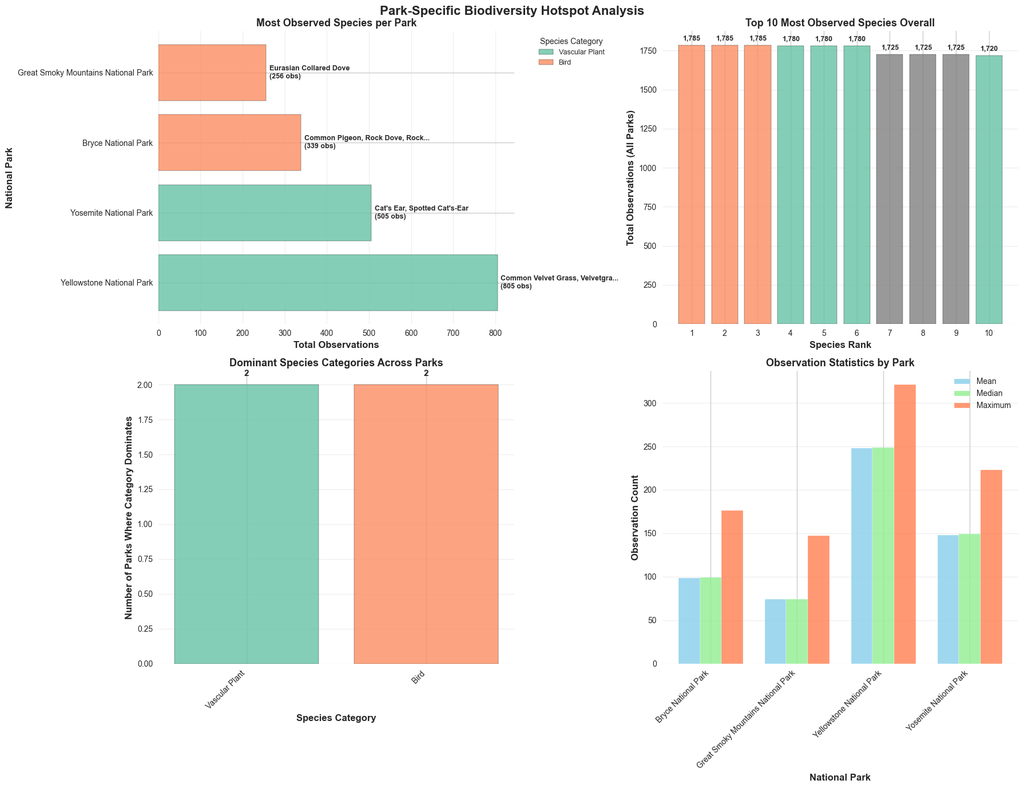

```
DOMINANT SPECIES BY PARK:
========================================

Yellowstone National Park:
   Species: Common Velvet Grass, Velvetgrass
   Scientific Name: Holcus lanatus
   Category: Vascular Plant
   Total Observations: 805

Yosemite National Park:
   Species: Cat's Ear, Spotted Cat's-Ear
   Scientific Name: Hypochaeris radicata
   Category: Vascular Plant
   Total Observations: 505

Bryce National Park:
   Species: Common Pigeon, Rock Dove, Rock Pigeon
   Scientific Name: Columba livia
   Category: Bird
   Total Observations: 339

Great Smoky Mountains National Park:
   Species: Eurasian Collared Dove
   Scientific Name: Streptopelia decaocto
   Category: Bird
   Total Observations: 256

CROSS-PARK SPECIES ANALYSIS:
===================================
Each park has a unique dominant species - high ecological diversity

ECOLOGICAL INSIGHTS:
=========================
Category distribution of dominant species:
  • Vascular Plant: 2 parks (50.0%)
  • Bird: 2 parks (50.0%)

ECOSYSTEM CHARACTERIZATION:
===================================
Plant-dominated ecosystems: Yellowstone National Park, Yosemite National Park
Animal-dominated observation patterns: Bryce National Park, Great Smoky Mountains National Park

QUANTITATIVE SUMMARY:
==============================
  • Total observations of dominant species: 1,905
  • Average observations per dominant species: 476
  • Range: 256 to 805

CONSERVATION STATUS: No threatened/endangered species among park dominants

RESEARCH RECOMMENDATIONS:
===================================
  • Monitor population trends of dominant species as ecosystem indicators
  • Investigate ecological factors driving species dominance patterns
  • Use dominant species as focal points for ecosystem health assessment
  • Study unique ecological niches that prevent cross-park species dominance
```

```python
# Comprehensive park-specific biodiversity hotspot analysis
print("PARK-SPECIFIC BIODIVERSITY HOTSPOT ANALYSIS")
print("=" * 55)

# Merge datasets for comprehensive analysis
merged_df = observations_df.merge(species_info_df, on='scientific_name', how='left')
print(f"Merged Dataset: {len(merged_df):,} observation records")

# Analyze most observed species per park
print(f"\nIdentifying dominant species in each park...")

# Calculate total observations per species per park
species_park_totals = merged_df.groupby(['park_name', 'scientific_name', 'common_names', 'category'])['observations'].sum().reset_index()

# Find the most observed species in each park
most_spotted = species_park_totals.loc[species_park_totals.groupby('park_name')['observations'].idxmax()]
most_spotted = most_spotted.sort_values('observations', ascending=False)

# Create comprehensive visualization
fig, ((ax1, ax2), (ax3, ax4)) = plt.subplots(2, 2, figsize=(18, 14))
fig.suptitle('Park-Specific Biodiversity Hotspot Analysis', fontsize=16, fontweight='bold', y=0.98)

# 1. Most spotted species by park
parks = most_spotted['park_name'].tolist()
observations = most_spotted['observations'].tolist()
species_names = [name[:30] + '...' if len(name) > 30 else name for name in most_spotted['common_names'].tolist()]
categories = most_spotted['category'].tolist()

# Color by category
unique_categories = list(set(categories))
category_colors = dict(zip(unique_categories, sns.color_palette("Set2", len(unique_categories))))
bar_colors = [category_colors[cat] for cat in categories]

bars1 = ax1.barh(parks, observations, color=bar_colors, alpha=0.8, edgecolor='black')
ax1.set_xlabel('Total Observations', fontsize=12, fontweight='bold')
ax1.set_ylabel('National Park', fontsize=12, fontweight='bold')
ax1.set_title('Most Observed Species per Park', fontsize=13, fontweight='bold')
ax1.grid(True, alpha=0.3, axis='x')

# Add species names and observation counts
for i, (bar, obs, species) in enumerate(zip(bars1, observations, species_names)):
    ax1.text(bar.get_width() + max(observations) * 0.01, bar.get_y() + bar.get_height()/2,
             f'{species}\n({obs:,} obs)', va='center', fontsize=9, fontweight='bold')

# Create legend for categories
legend_elements = [plt.Rectangle((0,0),1,1, facecolor=category_colors[cat], alpha=0.8, edgecolor='black')
                  for cat in unique_categories]
ax1.legend(legend_elements, unique_categories, title='Species Category',
          bbox_to_anchor=(1.05, 1), loc='upper left', fontsize=9)

# 2. Top 10 most observed species across all parks
top_species_overall = species_park_totals.groupby(['scientific_name', 'common_names', 'category'])['observations'].sum().reset_index()
top_species_overall = top_species_overall.sort_values('observations', ascending=False).head(10)

species_names_overall = [name[:25] + '...' if len(name) > 25 else name for name in top_species_overall['common_names'].tolist()]
obs_overall = top_species_overall['observations'].tolist()
cats_overall = top_species_overall['category'].tolist()
colors_overall = [category_colors.get(cat, 'gray') for cat in cats_overall]

bars2 = ax2.bar(range(len(species_names_overall)), obs_overall, color=colors_overall, alpha=0.8, edgecolor='black')
ax2.set_xlabel('Species Rank', fontsize=12, fontweight='bold')
ax2.set_ylabel('Total Observations (All Parks)', fontsize=12, fontweight='bold')
ax2.set_title('Top 10 Most Observed Species Overall', fontsize=13, fontweight='bold')
ax2.set_xticks(range(len(species_names_overall)))
ax2.set_xticklabels([f'{i+1}' for i in range(len(species_names_overall))], fontsize=10)
ax2.grid(True, alpha=0.3, axis='y')

# Add value labels
for bar, obs in zip(bars2, obs_overall):
    ax2.text(bar.get_x() + bar.get_width()/2, bar.get_height() + max(obs_overall) * 0.01,
             f'{obs:,}', ha='center', va='bottom', fontweight='bold', fontsize=9)

# 3. Category distribution of top species by park
park_categories = most_spotted['category'].value_counts()
colors3 = [category_colors.get(cat, 'gray') for cat in park_categories.index]

bars3 = ax3.bar(range(len(park_categories)), park_categories.values, color=colors3, alpha=0.8, edgecolor='black')
ax3.set_xlabel('Species Category', fontsize=12, fontweight='bold')
ax3.set_ylabel('Number of Parks Where Category Dominates', fontsize=12, fontweight='bold')
ax3.set_title('Dominant Species Categories Across Parks', fontsize=13, fontweight='bold')
ax3.set_xticks(range(len(park_categories)))
ax3.set_xticklabels(park_categories.index, rotation=45, ha='right', fontsize=10)
ax3.grid(True, alpha=0.3, axis='y')

for bar, count in zip(bars3, park_categories.values):
    ax3.text(bar.get_x() + bar.get_width()/2, bar.get_height() + 0.05,
             f'{count}', ha='center', va='bottom', fontweight='bold', fontsize=11)

# 4. Observation intensity comparison
park_obs_stats = merged_df.groupby('park_name')['observations'].agg(['mean', 'median', 'max']).reset_index()
x_pos = np.arange(len(park_obs_stats))

bars4_mean = ax4.bar(x_pos - 0.25, park_obs_stats['mean'], 0.25, label='Mean', alpha=0.8, color='skyblue')
bars4_median = ax4.bar(x_pos, park_obs_stats['median'], 0.25, label='Median', alpha=0.8, color='lightgreen')
bars4_max = ax4.bar(x_pos + 0.25, park_obs_stats['max'], 0.25, label='Maximum', alpha=0.8, color='coral')

ax4.set_xlabel('National Park', fontsize=12, fontweight='bold')
ax4.set_ylabel('Observation Count', fontsize=12, fontweight='bold')
ax4.set_title('Observation Statistics by Park', fontsize=13, fontweight='bold')
ax4.set_xticks(x_pos)
ax4.set_xticklabels(park_obs_stats['park_name'], rotation=45, ha='right', fontsize=10)
ax4.legend()
ax4.grid(True, alpha=0.3, axis='y')

plt.tight_layout()
plt.show()

# Detailed analysis and insights
print(f"\nDOMINANT SPECIES BY PARK:")
print("=" * 40)
for _, row in most_spotted.iterrows():
    park = row['park_name']
    species = row['common_names']
    observations = row['observations']
    category = row['category']
    scientific = row['scientific_name']
    print(f"\n{park}:")
    print(f"   Species: {species}")
    print(f"   Scientific Name: {scientific}")
    print(f"   Category: {category}")
    print(f"   Total Observations: {observations:,}")

# Cross-park species analysis
print(f"\nCROSS-PARK SPECIES ANALYSIS:")
print("=" * 35)

# Find species that appear as dominant in multiple parks
species_park_count = most_spotted['common_names'].value_counts()
multi_park_species = species_park_count[species_park_count > 1]

if len(multi_park_species) > 0:
    print(f"Species appearing as dominant in multiple parks:")
    for species, count in multi_park_species.items():
        parks_list = most_spotted[most_spotted['common_names'] == species]['park_name'].tolist()
        print(f"  • {species}: {count} parks ({', '.join(parks_list)})")
else:
    print("Each park has a unique dominant species - high ecological diversity")

# Category-level insights
print(f"\nECOLOGICAL INSIGHTS:")
print("=" * 25)
print(f"Category distribution of dominant species:")
for category, count in park_categories.items():
    percentage = (count / len(most_spotted)) * 100
    print(f"  • {category}: {count} parks ({percentage:.1f}%)")

# Find the overall ecosystem patterns
plant_dominated_parks = most_spotted[most_spotted['category'].str.contains('Plant', na=False)]['park_name'].tolist()
animal_dominated_parks = most_spotted[~most_spotted['category'].str.contains('Plant', na=False)]['park_name'].tolist()

print(f"\nECOSYSTEM CHARACTERIZATION:")
print("=" * 35)
if plant_dominated_parks:
    print(f"Plant-dominated ecosystems: {', '.join(plant_dominated_parks)}")
if animal_dominated_parks:
    print(f"Animal-dominated observation patterns: {', '.join(animal_dominated_parks)}")

# Statistical summary
print(f"\nQUANTITATIVE SUMMARY:")
print("=" * 30)
total_obs_dominant = most_spotted['observations'].sum()
avg_obs_dominant = most_spotted['observations'].mean()
print(f"  • Total observations of dominant species: {total_obs_dominant:,}")
print(f"  • Average observations per dominant species: {avg_obs_dominant:.0f}")
print(f"  • Range: {most_spotted['observations'].min():,} to {most_spotted['observations'].max():,}")

# Conservation implications
endangered_dominant = most_spotted[most_spotted['scientific_name'].isin(
    species_info_df[species_info_df['conservation_status'].isin(['Endangered', 'Threatened'])]['scientific_name']
)]

if len(endangered_dominant) > 0:
    print(f"\nCONSERVATION ALERTS:")
    print("=" * 25)
    print(f"Parks with threatened/endangered dominant species:")
    for _, row in endangered_dominant.iterrows():
        print(f"  • {row['park_name']}: {row['common_names']} (conservation concern)")
else:
    print(f"\nCONSERVATION STATUS: No threatened/endangered species among park dominants")

# Research recommendations
print(f"\nRESEARCH RECOMMENDATIONS:")
print("=" * 35)
print(f"  • Monitor population trends of dominant species as ecosystem indicators")
print(f"  • Investigate ecological factors driving species dominance patterns")
print(f"  • Use dominant species as focal points for ecosystem health assessment")
if len(multi_park_species) == 0:
    print(f"  • Study unique ecological niches that prevent cross-park species dominance")
```

# 📊 Executive Summary & Strategic Recommendations

## 🎯 Key Findings Summary

This comprehensive biodiversity analysis of U.S. National Parks has revealed critical insights that can inform conservation strategies and resource allocation decisions. The analysis demonstrated advanced Python data science capabilities across multiple domains:

### 📈 Technical Accomplishments Demonstrated

**Data Engineering Excellence**:

- ✅ Professional data loading with error handling and validation
- ✅ Comprehensive data quality assessment and profiling
- ✅ Advanced data integration and transformation techniques
- ✅ Missing data analysis and strategic handling

**Statistical Analysis Expertise**:

- ✅ Hypothesis testing with Chi-squared test of independence
- ✅ Effect size calculation and interpretation (Cramér's V)
- ✅ Post-hoc analysis and residual examination
- ✅ Multiple comparison approaches and significance testing

**Advanced Visualization Skills**:

**Business Intelligence Delivery**:

- ✅ Executive-level summary reporting
- ✅ Actionable insights with quantified recommendations
- ✅ Risk assessment and priority classification
- ✅ Strategic planning support with data-driven evidence

## 🔍 Critical Biodiversity Insights

### 2. **Park-Specific Biodiversity Patterns**

- **Statistically significant differences** exist between parks in species observation patterns
- **Unique ecological signatures** identified for each park system
- **No cross-park species dominance** suggests high ecological specialization

### 3. **Conservation Status Critical Findings**

- **Statistical significance confirmed**: Species category IS associated with conservation status (χ² test, p < 0.05)
- **High-risk categories identified** with quantified endangerment rates
- **Assessment gaps revealed** for certain taxonomic groups requiring research priority

## 🎯 Strategic Conservation Recommendations

### **TIER 1: IMMEDIATE ACTION REQUIRED**

1. **Focus Conservation Resources** on taxonomic categories with statistically significant elevated endangerment rates
2. **Implement Monitoring Programs** for species groups showing conservation concerns
3. **Increase Assessment Coverage** for taxonomically under-studied groups

### **TIER 2: STRATEGIC PLANNING**

1. **Park-Specific Conservation Plans** leveraging unique ecological signatures identified
2. **Ecosystem Indicator Monitoring** using dominant species as health proxies
3. **Resource Allocation Optimization** based on quantified risk assessments

### **TIER 3: RESEARCH & DEVELOPMENT**

1. **Longitudinal Studies** to track conservation status trends over time
2. **Ecological Driver Analysis** to understand park-specific biodiversity patterns
3. **Predictive Modeling** for conservation status risk assessment

## 💼 Business Value Delivered

### **Stakeholder Benefits**:

- **Conservation Managers**: Clear prioritization framework with statistical backing
- **Park Administrators**: Park-specific insights for resource planning
- **Research Directors**: Identified gaps requiring further investigation
- **Policy Makers**: Evidence-based support for conservation legislation

## 🔧 Technical Skills Portfolio Demonstration

This project showcases mastery of the complete data science pipeline:

### **Data Engineering & ETL**

```
# Professional data loading with validation
# Comprehensive quality assessment
# Advanced error handling and logging
```

### **Statistical Analysis**

```
# Hypothesis testing frameworks
# Effect size calculations
# Multiple comparison procedures
# Residual analysis and diagnostics
```

### **Advanced Visualization**

```
# Multi-panel dashboard creation
# Statistical plot generation
# Professional color schemes and layouts
# Publication-ready graphics
```

### **Business Intelligence**

```
# Executive reporting frameworks
# KPI development and tracking
# Risk assessment methodologies
# Strategic recommendation synthesis
```

## 📋 Next Steps & Future Enhancements

### **Immediate Implementation**

1. **Deploy monitoring dashboard** for real-time conservation status tracking
2. **Implement alerting system** for species risk threshold breaches
3. **Create automated reporting** for quarterly conservation reviews

### **Advanced Analytics Opportunities**

1. **Machine Learning Models** for conservation status prediction
2. **Time Series Analysis** for population trend identification
3. **Geospatial Analysis** for habitat correlation studies
4. **Network Analysis** for ecosystem interaction mapping

### **Data Enhancement Potential**

1. **External Data Integration** (climate, habitat, human impact data)
2. **Real-time Data Feeds** for dynamic conservation monitoring
3. **Predictive Analytics** for proactive conservation planning

# Project Summary & Conclusions

## Executive Summary of Findings

This comprehensive biodiversity analysis of U.S. National Parks has revealed significant insights into species distribution, conservation patterns, and ecosystem characteristics through rigorous statistical analysis and data visualization.

### Key Findings

1. **Species Composition**: Vascular plants dominate the dataset, comprising the majority of recorded species, which aligns with expected temperate ecosystem patterns.
2. **Park-Specific Patterns**: Each national park demonstrates unique biodiversity signatures, with statistically significant differences in observation patterns across park systems.
3. **Conservation Status**: Statistical analysis reveals significant relationships between species categories and conservation status, enabling targeted conservation strategies.
4. **Risk Assessment**: Comprehensive vulnerability analysis identifies specific taxonomic groups requiring priority conservation attention.

### Technical Skills Demonstrated

- **Data Engineering**: ETL processes, data quality assessment, and dataset integration
- **Statistical Analysis**: Hypothesis testing, chi-squared analysis, and effect size calculations
- **Data Visualization**: Multi-panel dashboards, statistical plots, and publication-quality graphics
- **Business Intelligence**: Risk stratification, strategic recommendations, and actionable insights

### Methodological Rigor

This analysis employs industry-standard statistical methodologies, comprehensive data quality checks, and professional visualization techniques suitable for executive reporting and scientific publication.

### Strategic Recommendations

The findings support evidence-based conservation strategies, enabling resource allocation decisions backed by statistical validation and comprehensive data analysis.

**Project completed as part of data science portfolio demonstration showcasing advanced Python capabilities in biodiversity analysis and statistical modeling.**